# Exercise 2: Data analysis (Regression and model validation)

```r
date()
```

```
## [1] "Fri Nov 12 19:24:52 2021"
```

### 1. Data exploration

```r
library(tidyverse)

#' read in data for analysis
lrn14 <- read.csv(here::here("data",
                             "lrn14_summ.csv")) %>%
  dplyr::select(gender, everything()) #' reorder columns

#' take a look at the data
dplyr::glimpse(lrn14)
```

```
## Rows: 166
## Columns: 7
## $ gender   <chr> "F", "F", "F", "F", "F", "F", "F", "F", "F", "F", "M", "F", "~
## $ Age      <int> 17, 18, 18, 18, 19, 19, 19, 19, 19, 19, 19, 20, 20, 20, 20, 2~
## $ Attitude <dbl> 1.7, 3.2, 3.7, 3.8, 1.9, 2.0, 3.2, 3.6, 3.7, 4.0, 1.9, 1.9, 2~
## $ Points   <int> 26, 17, 18, 28, 23, 20, 24, 30, 18, 27, 12, 12, 21, 20, 19, 2~
## $ deep     <dbl> 3.916667, 4.500000, 3.166667, 3.166667, 3.250000, 4.083333, 4~
## $ stra     <dbl> 4.625, 3.375, 2.625, 4.000, 3.875, 3.375, 3.625, 2.625, 2.625~
## $ surf     <dbl> 3.416667, 3.166667, 3.416667, 2.250000, 3.000000, 2.833333, 2~
```

The data comes from the international survey of Approaches to Learning, supported by the Teachers’ Academy funding for KV in 2013-2015. The data consists of 166 individuals and 7 variables. There are two descriptive variables: age and gender, and 5 variables that represent the cumulative results of the questionnaires in the survey. These are **“points”** (total exam points for each individual), **“attitude”** (global attitude towards statistics, cumulative sum of 10 questions ranking from 1-5), **“deep”** (a set of questions targeting the deep approach to learning), **“stra”** (strategic approach to learning), and **“surf”** (surface approach to learning).

Further details and explanations regarding this dataset can be found [here](https://www.mv.helsinki.fi/home/kvehkala/JYTmooc/JYTOPKYS3-meta.txt)

### 2. Graphical overview and summaries

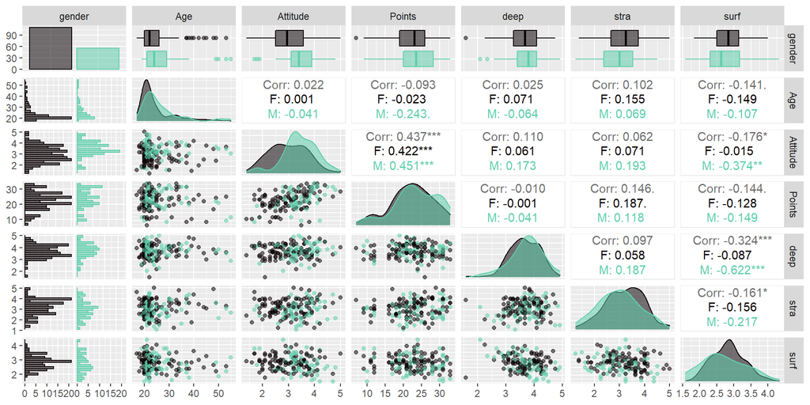

```r
library(GGally)

#' plot grahic summary of variables
GGally::ggpairs(lrn14,
                mapping = aes(col = gender,
                              fill = gender,
                              alpha = 0.2),
                lower = list(combo = GGally::wrap("facethist",
                                                  bins = 20))) +
  #' assign fill and colour
  viridis::scale_colour_viridis(option = "G",
                                end = 0.8,
                                discrete = T) +
  viridis::scale_fill_viridis(option = "G",
                              end = 0.8,
                              discrete = T)
```

### Regression mode and validation

Using exam points (points) as our dependent variable, we will fit a linear model to determine which independent variables are most crucial in explain the distribution of exam points in the dataset. Attitude is the first choice since it was seen to be highly correlated with exam points. We also add the variables surf and stra to the model since they are also seen to be marginally correlated.

```r
#' linear model
lm_mdl <- stats::lm(formula = Points ~ Attitude + surf + stra,
                    data = lrn14)

#' model summary
summary(lm_mdl)
```

```
##
## Call:
## stats::lm(formula = Points ~ Attitude + surf + stra, data = lrn14)
##
## Residuals:
##      Min       1Q   Median       3Q      Max
## -17.1550  -3.4346   0.5156   3.6401  10.8952
##
## Coefficients:
##             Estimate Std. Error t value Pr(>|t|)
## (Intercept)  11.0171     3.6837   2.991  0.00322 **
## Attitude      3.3952     0.5741   5.913 1.93e-08 ***
## surf         -0.5861     0.8014  -0.731  0.46563
## stra          0.8531     0.5416   1.575  0.11716
## ---
## Signif. codes:  0 '***' 0.001 '**' 0.01 '*' 0.05 '.' 0.1 ' ' 1
##
## Residual standard error: 5.296 on 162 degrees of freedom
## Multiple R-squared:  0.2074, Adjusted R-squared:  0.1927
## F-statistic: 14.13 on 3 and 162 DF,  p-value: 3.156e-08
```

```r
#' linear model
lm_mdl <- stats::lm(formula = Points ~ Attitude,
                    data = lrn14)

#' summary
summary(lm_mdl)
```

```
##
## Call:
## stats::lm(formula = Points ~ Attitude, data = lrn14)
##
## Residuals:
##      Min       1Q   Median       3Q      Max
## -16.9763  -3.2119   0.4339   4.1534  10.6645
##
## Coefficients:
##             Estimate Std. Error t value Pr(>|t|)
## (Intercept)  11.6372     1.8303   6.358 1.95e-09 ***
## Attitude      3.5255     0.5674   6.214 4.12e-09 ***
## ---
## Signif. codes:  0 '***' 0.001 '**' 0.01 '*' 0.05 '.' 0.1 ' ' 1
##
## Residual standard error: 5.32 on 164 degrees of freedom
## Multiple R-squared:  0.1906, Adjusted R-squared:  0.1856
## F-statistic: 38.61 on 1 and 164 DF,  p-value: 4.119e-09
```

Our new model still explains ~19% of the distribution (R2 = 0.1856) and attitude is statistically significant.

## Diagnostic plots

Next, we validate our model by plotting some diagnostics plots

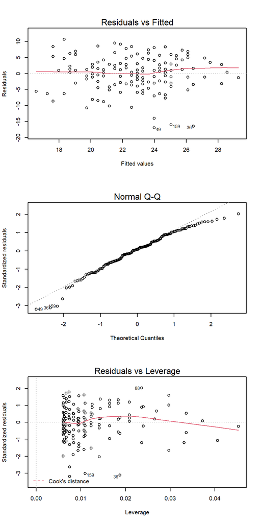

```r
#' diagnostic plots
par(mfrow = c(3, 1))
plot(lm_mdl, which = c(1,2,5))
```

**Residuals vs Fitted plot:** These plots illustrated the patterns of the residuals. While using a linear model, it is crucial to know that the residuals to not exhibit any non-linear patterns which would need alternative model to capture. The residuals look fairly linear in our plot, which would indicated that the linear model was the correct choice.

**Residuals vs Leverage plot:** The plot indicates whether there are standout samples that are highly influential towards the overall distribution and regression analysis reuslts. Such cases/samples would cross dashed lines in the upper and lower right corners of the plot, which represent the Cooks distance. No such instances are observed in our plots, which means there are no highly influential samples present in our data.